# Project 2 - Real Estate

A banking institution requires actionable insights into mortgage-backed securities, geographic business investment, and real estate analysis. The mortgage bank would like to identify potential monthly mortgage expenses for each region based on monthly family income and rental of the real estate. A statistical model needs to be created to predict the potential demand in dollars amount of loan for each of the region in the USA. Also, there is a need to create a dashboard which would refresh periodically post data retrieval from the agencies. The dashboard must demonstrate relationships and trends for the key metrics as follows: number of loans, average rental income, monthly mortgage and owner’s cost, family income vs mortgage cost comparison across different regions. The metrics described here do not limit the dashboard to these few.

### Project Task: Week1

##### Import data.

1. Figure out the primary key and look for the requirement of indexing.
2. Gauge the fill rate of the variables and devise plans for missing value treatment. Please explain explicitly the reason for the treatment chosen for each variable.

```python
# Importing libraries
import pandas as pd
import numpy as np
# I did not have this so did install - !pip install missingno
import missingno as msno
import matplotlib.pyplot as plt
%matplotlib inline
import seaborn as sns
```

```python
#Reading csv file into df
df_train = pd.read_csv("C:\\Users\\psing130\\Desktop\\DS\\Capstone\\Project\\train.csv")
df_test = pd.read_csv("C:\\Users\\psing130\\Desktop\\DS\\Capstone\\Project\\test.csv")
```

```python
#Checking dimesions first
print(f"Train has Row: {df_train.shape[0]} and Columns: {df_train.shape[1]}.")
print(f"Test has Row: {df_test.shape[0]} and Columns: {df_test.shape[1]}.")
```

```
Train has Row: 27321 and Columns: 80.
Test has Row: 11709 and Columns: 80.
```

## Exploring the data set read just now

```python
df_train.info()
```

```
<class 'pandas.core.frame.DataFrame'>
RangeIndex: 27321 entries, 0 to 27320
Data columns (total 80 columns):
UID                            27321 non-null int64
BLOCKID                        0 non-null float64
SUMLEVEL                       27321 non-null int64
COUNTYID                       27321 non-null int64
STATEID                        27321 non-null int64
state                          27321 non-null object
state_ab                       27321 non-null object
city                           27321 non-null object
place                          27321 non-null object
type                           27321 non-null object
primary                        27321 non-null object
zip_code                       27321 non-null int64
area_code                      27321 non-null int64
lat                            27321 non-null float64
lng                            27321 non-null float64
ALand                          27321 non-null float64
AWater                         27321 non-null int64
pop                            27321 non-null int64
male_pop                       27321 non-null int64
female_pop                     27321 non-null int64
rent_mean                      27007 non-null float64
rent_median                    27007 non-null float64
rent_stdev                     27007 non-null float64
rent_sample_weight             27007 non-null float64
rent_samples                   27007 non-null float64
rent_gt_10                     27007 non-null float64
rent_gt_15                     27007 non-null float64
rent_gt_20                     27007 non-null float64
rent_gt_25                     27007 non-null float64
rent_gt_30                     27007 non-null float64
rent_gt_35                     27007 non-null float64
rent_gt_40                     27007 non-null float64
rent_gt_50                     27007 non-null float64
universe_samples               27321 non-null int64
used_samples                   27321 non-null int64
hi_mean                        27053 non-null float64
hi_median                      27053 non-null float64
```

[output cut: 30 more lines]

```
male_age_stdev                 27132 non-null float64
male_age_sample_weight         27132 non-null float64
male_age_samples               27132 non-null float64
female_age_mean                27115 non-null float64
female_age_median              27115 non-null float64
female_age_stdev               27115 non-null float64
female_age_sample_weight       27115 non-null float64
female_age_samples             27115 non-null float64
pct_own                        27053 non-null float64
married                        27130 non-null float64
married_snp                    27130 non-null float64
separated                      27130 non-null float64
divorced                       27130 non-null float64
dtypes: float64(62), int64(12), object(6)
memory usage: 16.7+ MB
```

```python
df_test.info()
```

```
<class 'pandas.core.frame.DataFrame'>
RangeIndex: 11709 entries, 0 to 11708
Data columns (total 80 columns):
UID                            11709 non-null int64
BLOCKID                        0 non-null float64
SUMLEVEL                       11709 non-null int64
COUNTYID                       11709 non-null int64
STATEID                        11709 non-null int64
state                          11709 non-null object
state_ab                       11709 non-null object
city                           11709 non-null object
place                          11709 non-null object
type                           11709 non-null object
primary                        11709 non-null object
zip_code                       11709 non-null int64
area_code                      11709 non-null int64
lat                            11709 non-null float64
lng                            11709 non-null float64
ALand                          11709 non-null int64
AWater                         11709 non-null int64
pop                            11709 non-null int64
male_pop                       11709 non-null int64
female_pop                     11709 non-null int64
rent_mean                      11561 non-null float64
rent_median                    11561 non-null float64
rent_stdev                     11561 non-null float64
rent_sample_weight             11561 non-null float64
rent_samples                   11561 non-null float64
rent_gt_10                     11560 non-null float64
rent_gt_15                     11560 non-null float64
rent_gt_20                     11560 non-null float64
rent_gt_25                     11560 non-null float64
rent_gt_30                     11560 non-null float64
rent_gt_35                     11560 non-null float64
rent_gt_40                     11560 non-null float64
rent_gt_50                     11560 non-null float64
universe_samples               11709 non-null int64
used_samples                   11709 non-null int64
hi_mean                        11587 non-null float64
hi_median                      11587 non-null float64
```

[output cut: 30 more lines]

```
male_age_stdev                 11625 non-null float64
male_age_sample_weight         11625 non-null float64
male_age_samples               11625 non-null float64
female_age_mean                11613 non-null float64
female_age_median              11613 non-null float64
female_age_stdev               11613 non-null float64
female_age_sample_weight       11613 non-null float64
female_age_samples             11613 non-null float64
pct_own                        11587 non-null float64
married                        11625 non-null float64
married_snp                    11625 non-null float64
separated                      11625 non-null float64
divorced                       11625 non-null float64
dtypes: float64(61), int64(13), object(6)
memory usage: 7.1+ MB
```

```python
#Figure out the primary key and look for the requirement of indexing.
df_train.set_index(keys=['UID'],inplace=True)
df_test.set_index(keys=['UID'],inplace=True)
```

```python
#checking each type for null values
null_count_int = df_train.select_dtypes('int64').isnull().sum().sum()
null_count_float = df_train.select_dtypes('float64').isnull().sum().sum()
null_count_object = df_train.select_dtypes('object').isnull().sum().sum()
print(f"Null counts: Integer: {null_count_int}, Float: {null_count_float}, Object: {null_count_object}")
```

```
Null counts: Integer: 0, Float: 46917, Object: 0
```

```python
#Checking Float further since null count found
null_count_float = df_train.select_dtypes('float64').isnull().sum()
null_count_float[null_count_float>0]
```

```
BLOCKID                        27321
rent_mean                        314
rent_median                      314
rent_stdev                       314
rent_sample_weight               314
rent_samples                     314
rent_gt_10                       314
rent_gt_15                       314
rent_gt_20                       314
rent_gt_25                       314
rent_gt_30                       314
rent_gt_35                       314
rent_gt_40                       314
rent_gt_50                       314
hi_mean                          268
hi_median                        268
hi_stdev                         268
hi_sample_weight                 268
hi_samples                       268
family_mean                      298
family_median                    298
family_stdev                     298
family_sample_weight             298
family_samples                   298
hc_mortgage_mean                 573
hc_mortgage_median               573
hc_mortgage_stdev                573
hc_mortgage_sample_weight        573
hc_mortgage_samples              573
hc_mean                          600
hc_median                        600
hc_stdev                         600
hc_samples                       600
hc_sample_weight                 600
home_equity_second_mortgage      457
second_mortgage                  457
home_equity                      457
debt                             457
second_mortgage_cdf              457
home_equity_cdf                  457
debt_cdf                         457
hs_degree                        190
hs_degree_male                   200
hs_degree_female                 223
male_age_mean                    189
male_age_median                  189
male_age_stdev                   189
male_age_sample_weight           189
male_age_samples                 189
female_age_mean                  206
female_age_median                206
female_age_stdev                 206
female_age_sample_weight         206
female_age_samples               206
pct_own                          268
married                          191
married_snp                      191
separated                        191
divorced                         191
dtype: int64
```

## Data Cleaning

Checking head() for each type to see first 5 rows

```python
df_train.select_dtypes('int64').head()
```

| UID | SUMLEVEL | COUNTYID | STATEID | zip_code | area_code | AWater | pop | male_pop | female_pop | universe_samples | used_samples |
| --- | --- | --- | --- | --- | --- | --- | --- | --- | --- | --- | --- |
| 267822 | 140 | 53 | 36 | 13346 | 315 | 1699120 | 5230 | 2612 | 2618 | 387 | 355 |
| 246444 | 140 | 141 | 18 | 46616 | 574 | 100363 | 2633 | 1349 | 1284 | 542 | 502 |
| 245683 | 140 | 63 | 18 | 46122 | 317 | 284193 | 6881 | 3643 | 3238 | 459 | 378 |
| 279653 | 140 | 127 | 72 | 927 | 787 | 0 | 2700 | 1141 | 1559 | 438 | 358 |
| 247218 | 140 | 161 | 20 | 66502 | 785 | 0 | 5637 | 2586 | 3051 | 1725 | 1540 |

```python
df_train.select_dtypes('float64').head()
```

| UID | BLOCKID | lat | lng | ALand | rent_mean | rent_median | rent_stdev | rent_sample_weight | rent_samples | rent_gt_10 | ... | female_age_mean | female_age_median | female_age_stdev | female_age_sample_weight | female_age_samples | pct_own | married | married_snp | separated | divorced |
| --- | --- | --- | --- | --- | --- | --- | --- | --- | --- | --- | --- | --- | --- | --- | --- | --- | --- | --- | --- | --- | --- |
| 267822 | NaN | 42.840812 | -75.501524 | 202183361.0 | 769.38638 | 784.0 | 232.63967 | 272.34441 | 362.0 | 0.86761 | ... | 44.48629 | 45.33333 | 22.51276 | 685.33845 | 2618.0 | 0.79046 | 0.57851 | 0.01882 | 0.01240 | 0.08770 |
| 246444 | NaN | 41.701441 | -86.266614 | 1560828.0 | 804.87924 | 848.0 | 253.46747 | 312.58622 | 513.0 | 0.97410 | ... | 36.48391 | 37.58333 | 23.43353 | 267.23367 | 1284.0 | 0.52483 | 0.34886 | 0.01426 | 0.01426 | 0.09030 |
| 245683 | NaN | 39.792202 | -86.515246 | 69561595.0 | 742.77365 | 703.0 | 323.39011 | 291.85520 | 378.0 | 0.95238 | ... | 42.15810 | 42.83333 | 23.94119 | 707.01963 | 3238.0 | 0.85331 | 0.64745 | 0.02830 | 0.01607 | 0.10657 |
| 279653 | NaN | 18.396103 | -66.104169 | 1105793.0 | 803.42018 | 782.0 | 297.39258 | 259.30316 | 368.0 | 0.94693 | ... | 47.77526 | 50.58333 | 24.32015 | 362.20193 | 1559.0 | 0.65037 | 0.47257 | 0.02021 | 0.02021 | 0.10106 |
| 247218 | NaN | 39.195573 | -96.569366 | 2554403.0 | 938.56493 | 881.0 | 392.44096 | 1005.42886 | 1704.0 | 0.99286 | ... | 24.17693 | 21.58333 | 11.10484 | 1854.48652 | 3051.0 | 0.13046 | 0.12356 | 0.00000 | 0.00000 | 0.03109 |

5 rows × 62 columns

```python
df_train.select_dtypes('object').head()
```

| UID | state | state_ab | city | place | type | primary |
| --- | --- | --- | --- | --- | --- | --- |
| 267822 | New York | NY | Hamilton | Hamilton | City | tract |
| 246444 | Indiana | IN | South Bend | Roseland | City | tract |
| 245683 | Indiana | IN | Danville | Danville | City | tract |
| 279653 | Puerto Rico | PR | San Juan | Guaynabo | Urban | tract |
| 247218 | Kansas | KS | Manhattan | Manhattan City | City | tract |

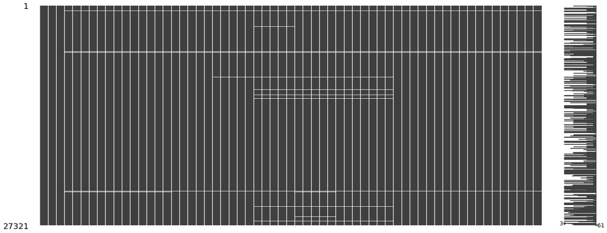

```python
# Since float had missing values so checking with missingno
msno.matrix(df_train.select_dtypes('float64'));
```

### Observation from above info:

1. Train and Test both have equal number of columns

### Type of data -

1. Train has Null values for float type
2. When population is 0, rent*,hi*, family_,hc*mortgage*,hc_ columns are null.
3. When AWater is 0 home_equity_second, second_mortgage, home_equity, debt, second_mortgage, home_equity, debt*cdf,hc* columns are null
4. When Male population is 0, male_ columns are null
5. When Female population is 0, female_ columns are null
6. When Male population or Female population is null, columns married, married_snp, separated, divorced are null ### Missing values handling:
7. BlockID and Sumlevel does not have any predictive power and no variance
8. Removing row when population is 0 or when Awater is 0
9. When Male population is 0, male_ columns imputing to 0
10. When Female population is 0, female_ columns imputing to 0
11. When Male population or Female popultation is null, imputing value 0 to columns married, married_snp, separated, divorced

```python
# BlockID and Sumlevel does not have any predictive power and no variance
df_train.drop(columns=['BLOCKID','SUMLEVEL'],inplace=True)
df_test.drop(columns=['BLOCKID','SUMLEVEL'],inplace=True)
```

```python
df_train.drop(df_train.index[df_train['pop'] == 0],inplace = True)
df_train.drop(df_train.index[df_train['AWater'] == 0],inplace = True)
df_test.drop(df_test.index[df_test['pop'] == 0],inplace = True)
df_test.drop(df_test.index[df_test['AWater'] == 0],inplace = True)
```

```python
df_train['male_age_mean'].fillna(0, inplace = True)
df_train['male_age_median'].fillna(0, inplace = True)
df_train['male_age_stdev'].fillna(0, inplace = True)
df_train['male_age_sample_weight'].fillna(0, inplace = True)
df_train['male_age_samples'].fillna(0, inplace = True)
df_train['female_age_mean'].fillna(0, inplace = True)
df_train['female_age_median'].fillna(0, inplace = True)
df_train['female_age_stdev'].fillna(0, inplace = True)
df_train['female_age_sample_weight'].fillna(0, inplace = True)
df_train['female_age_samples'].fillna(0, inplace = True)
df_train['married'].fillna(0, inplace = True)
df_train['married_snp'].fillna(0, inplace = True)
df_train['separated'].fillna(0, inplace = True)
df_train['divorced'].fillna(0, inplace = True)

df_test['male_age_mean'].fillna(0, inplace = True)
df_test['male_age_median'].fillna(0, inplace = True)
df_test['male_age_stdev'].fillna(0, inplace = True)
df_test['male_age_sample_weight'].fillna(0, inplace = True)
df_test['male_age_samples'].fillna(0, inplace = True)
df_test['female_age_mean'].fillna(0, inplace = True)
df_test['female_age_median'].fillna(0, inplace = True)
df_test['female_age_stdev'].fillna(0, inplace = True)
df_test['female_age_sample_weight'].fillna(0, inplace = True)
df_test['female_age_samples'].fillna(0, inplace = True)
df_test['married'].fillna(0, inplace = True)
df_test['married_snp'].fillna(0, inplace = True)
df_test['separated'].fillna(0, inplace = True)
df_test['divorced'].fillna(0, inplace = True)
```

```python
#Checking Float further since null count found
df_train.fillna(0, inplace = True)
df_test.fillna(0, inplace = True)
null_count_float = df_train.select_dtypes('float64').isnull().sum()
null_count_float[null_count_float>0]
```

```
Series([], dtype: int64)
```

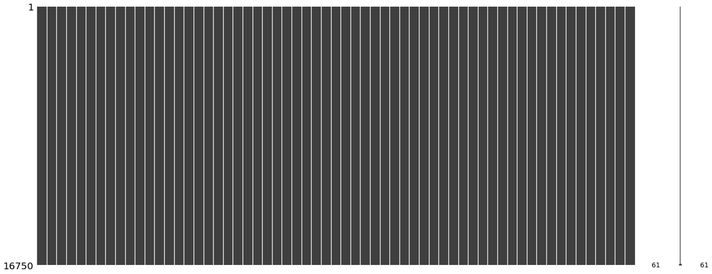

```python
# Since float had missing values so checking with missingno
msno.matrix(df_train.select_dtypes('float64'));
```

No Null values

##### Exploratory Data Analysis (EDA):

```
4.Perform debt analysis. You may take the following steps:
```

a) Explore the top 2,500 locations where the percentage of households with a second mortgage is the highest and percent ownership is above 10 percent. Visualize using geo-map. You may keep the upper limit for the percent of households with a second mortgage to 50 percent b) Use the following bad debt equation: Bad Debt = P (Second Mortgage n Home Equity Loan) Bad Debt = second_mortgage + home_equity - home_equity_second_mortgage c) Create pie charts to show overall debt and bad debt d) Create Box and whisker plot and analyze the distribution for 2nd mortgage, home equity, good debt, and bad debt for different cities e) Create a collated income distribution chart for family income, house hold income, and remaining income

```python
from pandasql import sqldf
q1 = "select place,pct_own,second_mortgage,lat,lng from df_train where pct_own >0.10 and second_mortgage <0.5 order by second_mortgage DESC LIMIT 2500;"
pysqldf = lambda q: sqldf(q, globals())
df_train_location_mort_pct=pysqldf(q1)
```

```python
df_train_location_mort_pct.head()
```

|  | place | pct_own | second_mortgage | lat | lng |
| --- | --- | --- | --- | --- | --- |
| 0 | Egypt Lake-leto | 0.11618 | 0.28972 | 28.029063 | -82.495395 |
| 1 | Lansing City | 1.00000 | 0.26667 | 42.714208 | -84.519179 |
| 2 | Louviers | 0.91609 | 0.23872 | 39.509438 | -105.063203 |
| 3 | Napa City | 0.20493 | 0.23810 | 38.294765 | -122.287773 |
| 4 | East Cleveland City | 0.33607 | 0.23529 | 41.527016 | -81.572525 |

```python
df_train['bad_debt']=df_train['second_mortgage']+df_train['home_equity']-df_train['home_equity_second_mortgage']
```

[figure not shown]

```python
df_train['bins'] = pd.cut(df_train['bad_debt'],bins=[0,0.10,1], labels=["less than 50%","50-100%"])
df_train.groupby(['bins']).size().plot(kind='pie',subplots=True,startangle=90, autopct='%1.1f%%')
plt.axis('equal')

plt.show()
#df.plot.pie(subplots=True,figsize=(8, 3))
```

```python
#Taking Hamilton and Manhattan cities data
cols=['second_mortgage','home_equity','debt','bad_debt']
df_box_hamilton=df_train.loc[df_train['city'] == 'Hamilton']
df_box_manhattan=df_train.loc[df_train['city'] == 'Manhattan']
df_box_city=pd.concat([df_box_hamilton,df_box_manhattan])
df_box_city.head(4)
```

| UID | COUNTYID | STATEID | state | state_ab | city | place | type | primary | zip_code | area_code | ... | female_age_stdev | female_age_sample_weight | female_age_samples | pct_own | married | married_snp | separated | divorced | bad_debt | bins |
| --- | --- | --- | --- | --- | --- | --- | --- | --- | --- | --- | --- | --- | --- | --- | --- | --- | --- | --- | --- | --- | --- |
| 267822 | 53 | 36 | New York | NY | Hamilton | Hamilton | City | tract | 13346 | 315 | ... | 22.51276 | 685.33845 | 2618.0 | 0.79046 | 0.57851 | 0.01882 | 0.01240 | 0.08770 | 0.09408 | less than 50% |
| 263797 | 21 | 34 | New Jersey | NJ | Hamilton | Yardville | City | tract | 8610 | 609 | ... | 24.05831 | 732.58443 | 3124.0 | 0.64400 | 0.56377 | 0.01980 | 0.00990 | 0.04892 | 0.18071 | 50-100% |
| 270979 | 17 | 39 | Ohio | OH | Hamilton | Hamilton City | Village | tract | 45015 | 513 | ... | 22.66500 | 565.32725 | 2528.0 | 0.61278 | 0.47397 | 0.04419 | 0.02663 | 0.13741 | 0.15005 | 50-100% |
| 259028 | 95 | 28 | Mississippi | MS | Hamilton | Hamilton | CDP | tract | 39746 | 662 | ... | 22.79602 | 483.01311 | 1954.0 | 0.83241 | 0.58678 | 0.01052 | 0.00000 | 0.11721 | 0.02130 | less than 50% |

4 rows × 79 columns

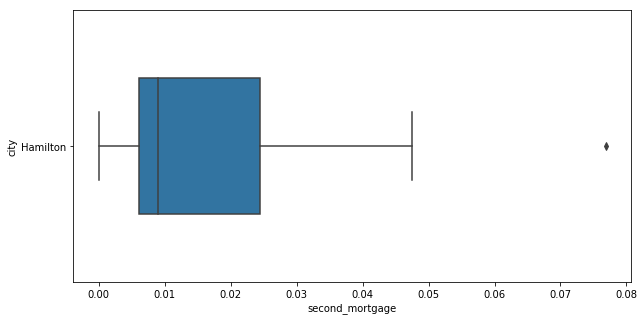

```python
plt.figure(figsize=(10,5))
sns.boxplot(data=df_box_city,x='second_mortgage', y='city',width=0.5)
plt.show()
```

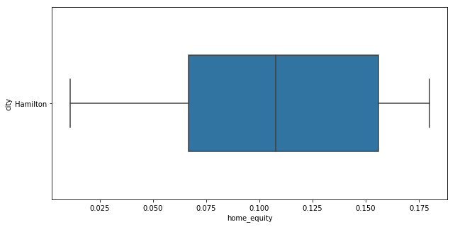

```python
plt.figure(figsize=(10,5))
sns.boxplot(data=df_box_city,x='home_equity', y='city',width=0.5)
plt.show()
```

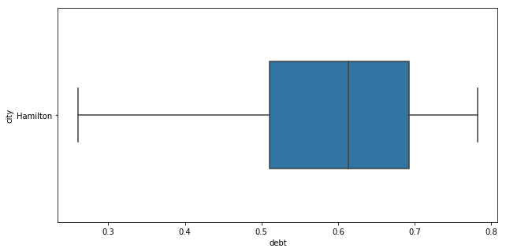

```python
plt.figure(figsize=(10,5))
sns.boxplot(data=df_box_city,x='debt', y='city',width=0.5)
plt.show()
```

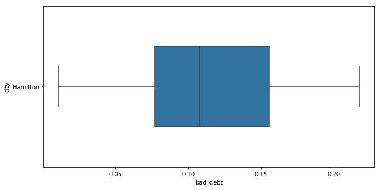

```python
plt.figure(figsize=(10,5))
sns.boxplot(data=df_box_city,x='bad_debt', y='city',width=0.5)
plt.show()
```

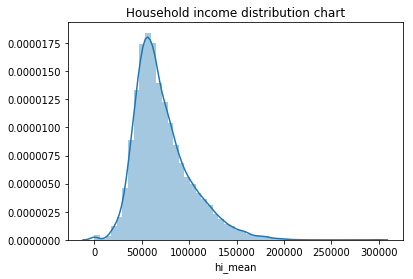

```python
#Create a collated income distribution chart for family income, house hold income, and remaining income
sns.distplot(df_train['hi_mean'])
plt.title('Household income distribution chart')
plt.show()
```

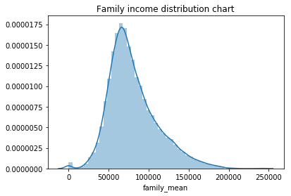

```python
sns.distplot(df_train['family_mean'])
plt.title('Family income distribution chart')
plt.show()
```

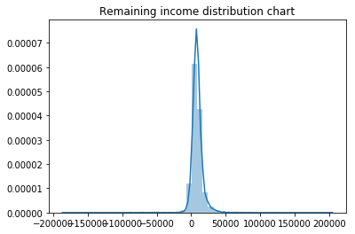

```python
sns.distplot(df_train['family_mean']-df_train['hi_mean'])
plt.title('Remaining income distribution chart')
plt.show()
```

### Project Task: Week 2

##### Exploratory Data Analysis (EDA):

1. Perform EDA and come out with insights into population density and age. You may have to derive new fields (make sure to weight averages for accurate measurements): a) Use pop and ALand variables to create a new field called population density b) Use male_age_median, female_age_median, male_pop, and female_pop to create a new field called median age c) Visualize the findings using appropriate chart type
2. Create bins for population into a new variable by selecting appropriate class interval so that the number of categories don’t exceed 5 for the ease of analysis. a) Analyze the married, separated, and divorced population for these population brackets b) Visualize using appropriate chart type
3. Please detail your observations for rent as a percentage of income at an overall level, and for different states.
4. Perform correlation analysis for all the relevant variables by creating a heatmap. Describe your findings.

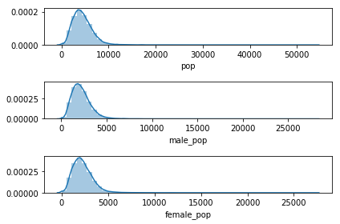

```python
#plt.figure(figsize=(25,10))
fig,(ax1,ax2,ax3)=plt.subplots(3,1)
sns.distplot(df_train['pop'],ax=ax1)
sns.distplot(df_train['male_pop'],ax=ax2)
sns.distplot(df_train['female_pop'],ax=ax3)
plt.subplots_adjust(wspace=0.8,hspace=0.8)
plt.tight_layout()
plt.show()
```

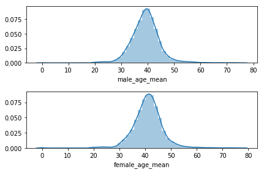

```python
#plt.figure(figsize=(25,10))
fig,(ax1,ax2)=plt.subplots(2,1)
sns.distplot(df_train['male_age_mean'],ax=ax1)
sns.distplot(df_train['female_age_mean'],ax=ax2)
plt.subplots_adjust(wspace=0.8,hspace=0.8)
plt.tight_layout()
plt.show()
```

```python
#population density
df_train['pop_density'] = df_train['pop']/df_train['ALand']
df_test['pop_density'] = df_test['pop']/df_test['ALand']
df_train['pop_density'].head(5)
```

```
UID
267822    0.000026
246444    0.001687
245683    0.000099
221087    0.000070
286689    0.000003
Name: pop_density, dtype: float64
```

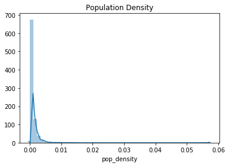

```python
sns.distplot(df_train['pop_density'])
plt.title('Population Density')
plt.show()
```

##### Very less density is noticed

```python
#median age
df_train['age_median']=(df_train['male_age_median']+df_train['female_age_median'])/2
df_test['age_median']=(df_test['male_age_median']+df_test['female_age_median'])/2
```

```python
df_train[['male_age_median','female_age_median','male_pop','female_pop','age_median']].head()
```

| UID | male_age_median | female_age_median | male_pop | female_pop | age_median |
| --- | --- | --- | --- | --- | --- |
| 267822 | 44.00000 | 45.33333 | 2612 | 2618 | 44.666665 |
| 246444 | 32.00000 | 37.58333 | 1349 | 1284 | 34.791665 |
| 245683 | 40.83333 | 42.83333 | 3643 | 3238 | 41.833330 |
| 221087 | 41.41667 | 36.41667 | 2564 | 2911 | 38.916670 |
| 286689 | 40.00000 | 42.75000 | 994 | 953 | 41.375000 |

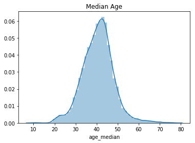

```python
sns.distplot(df_train['age_median'])
plt.title('Median Age')
plt.show()
```

##### Observation

1. Age of population is mostly between 20 and 60
2. Majority are of age around 40
3. Median age distribution has a gaussian distribution
4. Some right skewness is noticed

[figure not shown]

```python
sns.boxplot(df_train['age_median'])
plt.title('Population Density')
plt.show()
```

```python
#Create bins for population into a new variable by selecting appropriate class interval so that the number of categories don’t exceed 5 for the ease of analysis.
df_train['pop'].describe()
```

```
count    16750.000000
mean      4487.255940
std       2292.498532
min          3.000000
25%       2993.000000
50%       4181.500000
75%       5607.500000
max      53812.000000
Name: pop, dtype: float64
```

```python
df_train['pop_bins']=pd.cut(df_train['pop'],bins=5,labels=['very low','low','medium','high','very high'])
```

```python
df_train[['pop','pop_bins']]
```

| UID | pop | pop_bins |
| --- | --- | --- |
| 267822 | 5230 | very low |
| 246444 | 2633 | very low |
| 245683 | 6881 | very low |
| 221087 | 5475 | very low |
| 286689 | 1947 | very low |
| 280558 | 3476 | very low |
| 227164 | 4139 | very low |
| 229818 | 2056 | very low |
| 221922 | 4332 | very low |
| 251800 | 4019 | very low |
| 284565 | 2155 | very low |
| 241586 | 5003 | very low |
| 242185 | 6870 | very low |
| 249599 | 6893 | very low |
| 280022 | 4437 | very low |
| 259011 | 1792 | very low |
| 262773 | 9478 | very low |
| 274935 | 5567 | very low |
| 227345 | 6233 | very low |
| 223188 | 4634 | very low |
| 236509 | 7546 | very low |
| 278415 | 4180 | very low |
| 289352 | 6708 | very low |
| 280432 | 5489 | very low |
| 254392 | 3161 | very low |
| 270847 | 4699 | very low |
| 253027 | 1770 | very low |
| 239477 | 1849 | very low |
| 266407 | 8953 | very low |
| 230415 | 6207 | very low |
| ... | ... | ... |
| 293266 | 5104 | very low |
| 220488 | 5447 | very low |
| 256187 | 2240 | very low |
| 231616 | 2731 | very low |
| 283229 | 3802 | very low |
| 262767 | 4566 | very low |
| 289459 | 5125 | very low |
| 239442 | 1581 | very low |
| 279612 | 2243 | very low |
| 244435 | 3731 | very low |
| 275660 | 2192 | very low |
| 247129 | 3592 | very low |
| 257851 | 4128 | very low |
| 243898 | 5783 | very low |
| 289477 | 2894 | very low |
| 251500 | 2328 | very low |
| 273303 | 3261 | very low |
| 251891 | 7477 | very low |
| 260812 | 2431 | very low |
| 250571 | 5308 | very low |
| 235863 | 8672 | very low |
| 276524 | 1578 | very low |
| 260906 | 2774 | very low |
| 232847 | 5503 | very low |
| 281184 | 9092 | very low |
| 283346 | 3464 | very low |
| 248210 | 3463 | very low |
| 277856 | 4155 | very low |
| 233000 | 2829 | very low |
| 287425 | 11542 | low |

16750 rows × 2 columns

```python
df_train['pop_bins'].value_counts()
```

```
very low     16545
low            188
medium           9
high             7
very high        1
Name: pop_bins, dtype: int64
```

```python
#Analyze the married, separated, and divorced population for these population brackets
df_train.groupby(by='pop_bins')[['married','separated','divorced']].count()
```

| pop_bins | married | separated | divorced |
| --- | --- | --- | --- |
| very low | 16545 | 16545 | 16545 |
| low | 188 | 188 | 188 |
| medium | 9 | 9 | 9 |
| high | 7 | 7 | 7 |
| very high | 1 | 1 | 1 |

```python
df_train.groupby(by='pop_bins')[['married','separated','divorced']].agg(["mean", "median"])
```

| pop_bins | married mean | married median | separated mean | separated median | divorced mean | divorced median |
| --- | --- | --- | --- | --- | --- | --- |
| very low | 0.536974 | 0.557030 | 0.017761 | 0.012400 | 0.103164 | 0.09916 |
| low | 0.592942 | 0.603595 | 0.015800 | 0.010245 | 0.075856 | 0.06824 |
| medium | 0.655737 | 0.618710 | 0.005003 | 0.004120 | 0.065927 | 0.06489 |
| high | 0.503359 | 0.335660 | 0.008141 | 0.002500 | 0.039030 | 0.01032 |
| very high | 0.734740 | 0.734740 | 0.004050 | 0.004050 | 0.030360 | 0.03036 |

##### Observation:

1. Very high population group has more married people and less percantage of separated and divorced couples
2. In very low population groups, there are more divorced people

```python
#Please detail your observations for rent as a percentage of income at an overall level, and for different states.
rent_state_mean=df_train.groupby(by='state')['rent_mean'].agg(["mean"])
rent_state_mean.head()
```

| state | mean |
| --- | --- |
| Alabama | 765.581109 |
| Alaska | 1164.898162 |
| Arizona | 1108.066981 |
| Arkansas | 717.342584 |
| California | 1470.168164 |

```python
income_state_mean=df_train.groupby(by='state')['family_mean'].agg(["mean"])
income_state_mean.head()
```

| state | mean |
| --- | --- |
| Alabama | 68355.095981 |
| Alaska | 92339.702126 |
| Arizona | 76198.315007 |
| Arkansas | 65355.839652 |
| California | 92927.113129 |

```python
rent_perc_of_income=rent_state_mean['mean']/income_state_mean['mean']
rent_perc_of_income.head(10)
```

```
state
Alabama                 0.011200
Alaska                  0.012615
Arizona                 0.014542
Arkansas                0.010976
California              0.015821
Colorado                0.013038
Connecticut             0.012062
Delaware                0.013192
District of Columbia    0.013021
Florida                 0.015351
Name: mean, dtype: float64
```

```python
#overall level rent as a percentage of income
sum(df_train['rent_mean'])/sum(df_train['family_mean'])
```

```
0.012504656207579429
```

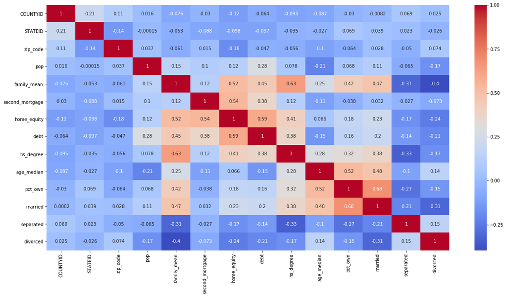

```python
#Perform correlation analysis for all the relevant variables by creating a heatmap. Describe your findings.
cor=df_train[['COUNTYID','STATEID','zip_code','type','pop', 'family_mean',
         'second_mortgage', 'home_equity', 'debt','hs_degree',
           'age_median','pct_own', 'married','separated', 'divorced']].corr()
plt.figure(figsize=(20,10))
sns.heatmap(cor,annot=True,cmap='coolwarm')
plt.show()
```

### Project Task: Week 3

##### Data Pre-processing:

1. The economic multivariate data has a significant number of measured variables. The goal is to find where the measured variables depend on a number of smaller unobserved common factors or latent variables.
2. Each variable is assumed to be dependent upon a linear combination of the common factors, and the coefficients are known as loadings. Each measured variable also includes a component due to independent random variability, known as “specific variance” because it is specific to one variable. Obtain the common factors and then plot the loadings. Use factor analysis to find latent variables in our dataset and gain insight into the linear relationships in the data. Following are the list of latent variables: • Highschool graduation rates • Median population age • Second mortgage statistics • Percent own • Bad debt expense

```python
df_train['type'].unique()
type_dict={'type':{'City':1,
                   'Urban':2,
                   'Town':3,
                   'CDP':4,
                   'Village':5,
                   'Borough':6}
          }
df_train.replace(type_dict,inplace=True)
```

```python
df_train['type'].unique()
```

```
array([1, 3, 4, 5, 6, 2], dtype=int64)
```

```python
df_test.replace(type_dict,inplace=True)
```

```python
df_test['type'].unique()
```

```
array([4, 1, 6, 3, 5, 2], dtype=int64)
```

```python
feature_cols=['COUNTYID','STATEID','zip_code','type','pop', 'family_mean',
         'second_mortgage', 'home_equity', 'debt','hs_degree',
           'age_median','pct_own', 'married','separated', 'divorced']
```

```python
x_train=df_train[feature_cols]
y_train=df_train['hc_mortgage_mean']
```

```python
x_test=df_test[feature_cols]
y_test=df_test['hc_mortgage_mean']
```

```python
from sklearn.preprocessing import StandardScaler
from sklearn.linear_model import LinearRegression
from sklearn.metrics import r2_score, mean_absolute_error,mean_squared_error,accuracy_score
```

```python
x_train.head()
```

| UID | COUNTYID | STATEID | zip_code | type | pop | family_mean | second_mortgage | home_equity | debt | hs_degree | age_median | pct_own | married | separated | divorced |
| --- | --- | --- | --- | --- | --- | --- | --- | --- | --- | --- | --- | --- | --- | --- | --- |
| 267822 | 53 | 36 | 13346 | 1 | 5230 | 67994.14790 | 0.02077 | 0.08919 | 0.52963 | 0.89288 | 44.666665 | 0.79046 | 0.57851 | 0.01240 | 0.08770 |
| 246444 | 141 | 18 | 46616 | 1 | 2633 | 50670.10337 | 0.02222 | 0.04274 | 0.60855 | 0.90487 | 34.791665 | 0.52483 | 0.34886 | 0.01426 | 0.09030 |
| 245683 | 63 | 18 | 46122 | 1 | 6881 | 95262.51431 | 0.00000 | 0.09512 | 0.73484 | 0.94288 | 41.833330 | 0.85331 | 0.64745 | 0.01607 | 0.10657 |
| 221087 | 79 | 1 | 35673 | 3 | 5475 | 60875.74450 | 0.00000 | 0.05991 | 0.43721 | 0.80537 | 38.916670 | 0.83215 | 0.58503 | 0.00000 | 0.16910 |
| 286689 | 337 | 48 | 76255 | 3 | 1947 | 68632.82777 | 0.00000 | 0.00000 | 0.34370 | 0.84475 | 41.375000 | 0.77658 | 0.63974 | 0.01410 | 0.09744 |

```python
sc=StandardScaler()
x_train_scaled=sc.fit_transform(x_train)
x_test_scaled=sc.fit_transform(x_test)
```

```python
#Running model at nation level
linereg=LinearRegression()
linereg.fit(x_train_scaled,y_train)
```

```
LinearRegression()
```

```python
y_pred=linereg.predict(x_test_scaled)
```

```python
print("Overall R2 score of linear regression model", r2_score(y_test,y_pred))
print("Overall RMSE of linear regression model", np.sqrt(mean_squared_error(y_test,y_pred)))
```

```
Overall R2 score of linear regression model 0.7679255812361618
Overall RMSE of linear regression model 296.1080182383934
```

##### Observation:

Accuracy and R2 score are good

```python
#Running model at state level
state=df_train['STATEID'].unique()
state[0:5]
```

```
array([36, 18,  1, 48, 45], dtype=int64)
```

```python
for i in [20,1,45]:
    print("State ID-",i)

    x_train_nation=df_train[df_train['COUNTYID']==i][feature_cols]
    y_train_nation=df_train[df_train['COUNTYID']==i]['hc_mortgage_mean']

    x_test_nation=df_test[df_test['COUNTYID']==i][feature_cols]
    y_test_nation=df_test[df_test['COUNTYID']==i]['hc_mortgage_mean']

    x_train_scaled_nation=sc.fit_transform(x_train_nation)
    x_test_scaled_nation=sc.fit_transform(x_test_nation)

    linereg.fit(x_train_scaled_nation,y_train_nation)
    y_pred_nation=linereg.predict(x_test_scaled_nation)

    print("Overall R2 score of linear regression model for state,",i,":-" ,r2_score(y_test_nation,y_pred_nation))
    print("Overall RMSE of linear regression model for state,",i,":-" ,np.sqrt(mean_squared_error(y_test_nation,y_pred_nation)))
    print("\n")
```

```
State ID- 20
Overall R2 score of linear regression model for state, 20 :- 0.2566703005026615
Overall RMSE of linear regression model for state, 20 :- 1265.6909064755544


State ID- 1
Overall R2 score of linear regression model for state, 1 :- 0.715425218219983
Overall RMSE of linear regression model for state, 1 :- 390.78212269359085


State ID- 45
Overall R2 score of linear regression model for state, 45 :- 0.685655178093099
Overall RMSE of linear regression model for state, 45 :- 262.21972886681107
```

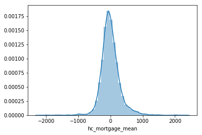

```python
#checking residuals
residuals=y_test-y_pred
sns.distplot(residuals);
```